# Analysis of Environmental Data - R Reference Guide

Sarah Guitart

2022-12-06

# R Reference Guide

## Loading Data and Packages

#### Library and Require

The functions library() and require() load packages to RStudio that are *already installed*. The functions are *case-sensitive*. The functions can be used almost interchangeably, but the main difference is that library() will give you an error message if the package doesn’t exist, while require() will only give you a warning. Library() *will not* let you proceed until you fix the error.

```r
## loading the palmerpenguin packages incorrectly at first with require, then correctly with library
require(Palmerpenguins)
library(palmerpenguins)
```

```r
## loading the package here with require
require(here)
```

#### Loading Files

```r
## loading the 2021 gingko datafile using here()
ginkgo <- read.csv(here("data", "ginkgo_data_2022.csv"))
head(ginkgo)
```

```
##   site_id seeds_present max_width max_depth notch_depth petiole_length
## 1     216         FALSE        85        59          12             91
## 2     216         FALSE        72        54           0             56
## 3     216         FALSE        64        42           0             71
## 4     216         FALSE        76        48           0             44
## 5     216         FALSE        85        50           5             40
## 6     216         FALSE        75        46           7             50
```

## Data Structures

#### c()

The function c() combines or concatenates its arguments into a vector (a 1-dimensional data structure consisting of 1 or more elements). All of the elements *must be of the same type*. You cannot combine characters and numeric types into the same vector with c(), but you can use a singular type of your choice. To store my vector, I need to assign them to an object. I can then call my object directly, or use the function print(), and my vector will appear.

```r
## create a vector of numbers
num_vec = c(1, 2, 3, 4, 5, 6)
num_vec
```

```
## [1] 1 2 3 4 5 6
```

```r
## create a vector of characters
char_vec = c("R", "can", "be", "pretty", "fun", "sometimes")
char_vec
```

```
## [1] "R"         "can"       "be"        "pretty"    "fun"       "sometimes"
```

```r
print(char_vec)
```

```
## [1] "R"         "can"       "be"        "pretty"    "fun"       "sometimes"
```

#### length()

The function length() tells you the length of data objects, lists, and vectors, or how many things are in your object. It works with characters too, but only in the sense that it tells you the individual character chunks of your vector.

```r
## what is the length of num_vec?
length(num_vec)
```

```
## [1] 6
```

```r
## what does it do with characters?
char2 = c("R can be", "pretty fun", "sometimes")
length(char2)
```

```
## [1] 3
```

```r
length(char_vec)
```

```
## [1] 6
```

#### matrix()

A matrix in R is a two dimensional arrangement of numbers in a specified number of rows and columns. You can create this by using the function matrix(). There are specific arguments within matrix(). You first need to tell it what data is going into the matrix, how many rows it will have, how many columns it will have, if it will sort the data by rows or by columns, and if the rows and columns will have names. Matrices in R can have *only one data type*.

Below I used num_vec to create a matrix with 2 columns and 3 rows, sorted by rows, and no names.

```r
m1 = matrix(num_vec, nrow = 3, ncol = 2, byrow = TRUE, dimname = NULL)
m1
```

```
##      [,1] [,2]
## [1,]    1    2
## [2,]    3    4
## [3,]    5    6
```

Here, I swapped the number of rows and columns.

```r
m2 = matrix(num_vec, nrow = 2, ncol = 3, byrow = TRUE, dimname = NULL)
m2
```

```
##      [,1] [,2] [,3]
## [1,]    1    2    3
## [2,]    4    5    6
```

Here, I sorted by columns.

```r
m3 = matrix(num_vec, nrow = 2, ncol = 3, byrow = FALSE, dimname = NULL)
m3
```

```
##      [,1] [,2] [,3]
## [1,]    1    3    5
## [2,]    2    4    6
```

```r
m4 = matrix(num_vec, nrow = 2, ncol = 4, byrow = FALSE, dimname = NULL)
m4
```

```
##      [,1] [,2] [,3] [,4]
## [1,]    1    3    5    1
## [2,]    2    4    6    2
```

Lastly, matrices can be made with characters, if you feel the need.

```r
## why not!
m5 = matrix(char_vec, nrow = 2, ncol = 6, byrow = TRUE, dimname = NULL)
m5
```

```
##      [,1] [,2]  [,3] [,4]     [,5]  [,6]
## [1,] "R"  "can" "be" "pretty" "fun" "sometimes"
## [2,] "R"  "can" "be" "pretty" "fun" "sometimes"
```

#### data.frame()

You can build a dataframe in R using the function data.frame().The cool thing about this function is that it’s pretty easy to build, but you can also *mix types*. This means you can have both number and characters in your dataframe. If I want to build a dataframe out of my current vectors, I can tell data.frame() what the names of my variables are.

```r
d = data.frame("numbers" = num_vec, "characters" = char_vec)
d
```

```
##   numbers characters
## 1       1          R
## 2       2        can
## 3       3         be
## 4       4     pretty
## 5       5        fun
## 6       6  sometimes
```

Additionally, I can build a dataframe from scratch.

```r
d2 = data.frame("numbers" = c(1:6), "characters" = c("one", "two", "three", "four", "five", "six"))
d2
```

```
##   numbers characters
## 1       1        one
## 2       2        two
## 3       3      three
## 4       4       four
## 5       5       five
## 6       6        six
```

#### nrow()

You can find out the number of rows your dataframe has by using the function nrow(). This is useful if you’re trying to figure out the number of observations your dataframe has.

```r
## how many rows does my dataframe have?
nrow(ginkgo)
```

```
## [1] 220
```

#### ncol()

You can find out the number of columns your dataframe has by using the function ncol(). This is useful if you’re trying to figure out how many variables your dataframe has.

```r
## how many columns does my dataframe have?
ncol(ginkgo)
```

```
## [1] 6
```

#### dim()

You can find out the dimensions of your object by using dim(). It will give you the number of rows and columns in your dataframe, *in that order*. As seen below, my dataframe has 220 rows and 6 columns.

```r
## what are the dimensions of my dataframe?
dim(ginkgo)
```

```
## [1] 220   6
```

## Subsetting

#### Subsetting by Name

To retrieve a column of your dataframe, you can subset it by using the format “objectname$variablename”. You can either simply call the column, or you can store it into a new object if you wish to manipulate it further. Note you can *only use this with columns, not rows*.

```r
## calling the column
ginkgo$max_width
```

```
##   [1]  85  72  64  76  85  75  72  81  87  87  94  92  70  84  61 102  82  64
##  [19]  53  66  69  55  56  64  60  59  57  53  68  56  75  63  82  83  60  67
##  [37]  75  92 110  54  77  59  51 100  92  77  99  62  80  86  63  79  91  72
##  [55]  64  53  71  61  70  93  75  87  86  87  95  88  85  95  95  52  84  74
##  [73]  87  76  57  92  94  79  97  50 100  97  63  96  97  70  83  80  85 100
##  [91] 112 115  83 106  95  80 120  76  50  90  94  69  93  59  60 103  95  90
## [109]  80  90 106  98  73  89  65  83 116  90  86 104  92 103 100  91 102  99
## [127]  98 104  80  68  62  77  86  72  70  63  72  65  69  67  35  67  63  71
## [145]  77  60  70  69  55  72  84 106  61 114  95  86  60  78  86  91  79  95
## [163]  72 102  72 107  95  91  94  90  98  63  58  67  92  75  74  73  73  94
## [181]  76  86  78  74  89  77  80  71  69  81  39  60  50  47  52  61  56  45
## [199]  64  42 103  84 118 120 100 111 104  94  78  70  92  48  79  91 111  44
## [217] 117  93 101 145
```

```r
## importing that column into a new object
max_width = ginkgo$max_width
head(max_width)
```

```
## [1] 85 72 64 76 85 75
```

#### Subsetting by Position

This is a pretty fun and more adaptable way to call something from your dataframe. Instead of using the variable *name*, you’re using “[]” to call its *physical position within the dataframe*. You can call whole rows, columns, or just singular elements. The order to call elements is [row, column]. You will have to know where your desired values live, but it’s pretty neat.

```r
## I want the first row, so I specify the row number I'm interested in, and then LEAVE THE COLUMN ENTRY BLANK. It will assume you're looking for the first column and return that instead.
## incorrect first
## correct second
ginkgo[1]
```

```
##     site_id
## 1       216
## 2       216
## 3       216
## 4       216
## 5       216
## 6       216
## 7       216
## 8       216
## 9       216
## 10      216
## 11     1896
## 12     1896
## 13     1896
## 14     1896
```

[output cut: 206 more lines]

```r
ginkgo[1,]
```

```
##   site_id seeds_present max_width max_depth notch_depth petiole_length
## 1     216         FALSE        85        59          12             91
```

```r
## calling one element only
ginkgo[2,3]
```

```
## [1] 72
```

```r
## selecting the third column only, leaving the row entry empty
ginkgo[,3]
```

```
##   [1]  85  72  64  76  85  75  72  81  87  87  94  92  70  84  61 102  82  64
##  [19]  53  66  69  55  56  64  60  59  57  53  68  56  75  63  82  83  60  67
##  [37]  75  92 110  54  77  59  51 100  92  77  99  62  80  86  63  79  91  72
##  [55]  64  53  71  61  70  93  75  87  86  87  95  88  85  95  95  52  84  74
##  [73]  87  76  57  92  94  79  97  50 100  97  63  96  97  70  83  80  85 100
##  [91] 112 115  83 106  95  80 120  76  50  90  94  69  93  59  60 103  95  90
## [109]  80  90 106  98  73  89  65  83 116  90  86 104  92 103 100  91 102  99
## [127]  98 104  80  68  62  77  86  72  70  63  72  65  69  67  35  67  63  71
## [145]  77  60  70  69  55  72  84 106  61 114  95  86  60  78  86  91  79  95
## [163]  72 102  72 107  95  91  94  90  98  63  58  67  92  75  74  73  73  94
## [181]  76  86  78  74  89  77  80  71  69  81  39  60  50  47  52  61  56  45
## [199]  64  42 103  84 118 120 100 111 104  94  78  70  92  48  79  91 111  44
## [217] 117  93 101 145
```

#### Subsetting by subset()

You can also subset data from your dataframe by using the function subset(). In this example, I will use the penguins dataframe to select rows only for Adelie penguins by telling R what I’m specifically interested in the species column. Like in previous examples, I can either just call the values, or I can store them in a separate data object.

```r
subset(penguins, species == "Adelie")
```

```
## # A tibble: 152 × 8
##    species island    bill_length_mm bill_depth_mm flipper_…¹ body_…² sex    year
##    <fct>   <fct>              <dbl>         <dbl>      <int>   <int> <fct> <int>
##  1 Adelie  Torgersen           39.1          18.7        181    3750 male   2007
##  2 Adelie  Torgersen           39.5          17.4        186    3800 fema…  2007
##  3 Adelie  Torgersen           40.3          18          195    3250 fema…  2007
##  4 Adelie  Torgersen           NA            NA           NA      NA <NA>   2007
##  5 Adelie  Torgersen           36.7          19.3        193    3450 fema…  2007
##  6 Adelie  Torgersen           39.3          20.6        190    3650 male   2007
##  7 Adelie  Torgersen           38.9          17.8        181    3625 fema…  2007
##  8 Adelie  Torgersen           39.2          19.6        195    4675 male   2007
##  9 Adelie  Torgersen           34.1          18.1        193    3475 <NA>   2007
## 10 Adelie  Torgersen           42            20.2        190    4250 <NA>   2007
## # … with 142 more rows, and abbreviated variable names ¹flipper_length_mm,
## #   ²body_mass_g
```

```r
adelie = subset(penguins, species == "Adelie")
adelie
```

```
## # A tibble: 152 × 8
##    species island    bill_length_mm bill_depth_mm flipper_…¹ body_…² sex    year
##    <fct>   <fct>              <dbl>         <dbl>      <int>   <int> <fct> <int>
##  1 Adelie  Torgersen           39.1          18.7        181    3750 male   2007
##  2 Adelie  Torgersen           39.5          17.4        186    3800 fema…  2007
##  3 Adelie  Torgersen           40.3          18          195    3250 fema…  2007
##  4 Adelie  Torgersen           NA            NA           NA      NA <NA>   2007
##  5 Adelie  Torgersen           36.7          19.3        193    3450 fema…  2007
##  6 Adelie  Torgersen           39.3          20.6        190    3650 male   2007
##  7 Adelie  Torgersen           38.9          17.8        181    3625 fema…  2007
##  8 Adelie  Torgersen           39.2          19.6        195    4675 male   2007
##  9 Adelie  Torgersen           34.1          18.1        193    3475 <NA>   2007
## 10 Adelie  Torgersen           42            20.2        190    4250 <NA>   2007
## # … with 142 more rows, and abbreviated variable names ¹flipper_length_mm,
## #   ²body_mass_g
```

## Numerical Data Exploration

#### summary()

The function summary() can give you quick summaries of the values in multiple data objects. Depending on the data type within your object, it will either give you a quick summary of the data, providing the minimum and maximum values, the 1st and 3rd quartiles, and the mean and median, or it will tell you the length of your vector, as well as it’s class and mode.

```r
## let's try something small
summary(num_vec)
```

```
##    Min. 1st Qu.  Median    Mean 3rd Qu.    Max.
##    1.00    2.25    3.50    3.50    4.75    6.00
```

```r
summary(char_vec)
```

```
##    Length     Class      Mode
##         6 character character
```

```r
## let's try something a little bigger
## let's get a summary of the maximum width of our ginkgo leaves
summary(ginkgo$max_width)
```

```
##    Min. 1st Qu.  Median    Mean 3rd Qu.    Max.
##   35.00   67.00   80.00   79.95   93.00  145.00
```

You can also summarize the whole dataframe, which will give you summaries by column.

```r
## the whole enchilada
summary(ginkgo)
```

```
##     site_id      seeds_present     max_width        max_depth
##  Min.   :  216   Mode :logical   Min.   : 35.00   Min.   : 24.0
##  1st Qu.: 3470   FALSE:180       1st Qu.: 67.00   1st Qu.: 45.0
##  Median : 4874   TRUE :40        Median : 80.00   Median : 53.0
##  Mean   : 5726                   Mean   : 79.95   Mean   : 53.1
##  3rd Qu.: 6719                   3rd Qu.: 93.00   3rd Qu.: 60.0
##  Max.   :12982                   Max.   :145.00   Max.   :125.0
##   notch_depth     petiole_length
##  Min.   : 0.000   Min.   : 13.00
##  1st Qu.: 0.000   1st Qu.: 45.00
##  Median : 2.000   Median : 58.00
##  Mean   : 5.977   Mean   : 59.51
##  3rd Qu.: 6.250   3rd Qu.: 71.00
##  Max.   :92.000   Max.   :126.00
```

#### mean()

The summary function provides us with the mean, but the function mean() can give us just the mean value, no muss, no fuss.

```r
## something small!
mean(num_vec)
```

```
## [1] 3.5
```

However, let’s say we create a new dataset that has a NA value.

```r
bad = c(1, 2, 3, 4, 5, 6, NA)
bad
```

```
## [1]  1  2  3  4  5  6 NA
```

```r
mean(bad)
```

```
## [1] NA
```

You can solve that but using the na.rm arugment within the mean() function

```r
## let's remove the NAs
mean(bad, na.rm = TRUE)
```

```
## [1] 3.5
```

Unfortunately, we can’t run mean() on our whole ginkgo dataframe, because it has non-numeric data types. That’s okay, because we can easily get the means of our individual columns.

```r
## trying the whole dataframe
mean(ginkgo, na.rm = TRUE)
```

```
## [1] NA
```

```r
## individual columns
mean(ginkgo$max_width, na.rm = TRUE)
```

```
## [1] 79.95455
```

```r
mean(ginkgo[,3], na.rm= TRUE)
```

```
## [1] 79.95455
```

#### sd()

The function to retrieve the standard deviation, sd(), functions exactly like the mean() function. You can also remove NA values within the function itself. Don’t forget that you can always store these outputs as their own object!

```r
sd(bad)
```

```
## [1] NA
```

```r
sd(bad, na.rm = TRUE)
```

```
## [1] 1.870829
```

```r
sd(ginkgo$max_width, na.rm = TRUE)
```

```
## [1] 18.16358
```

```r
sd(ginkgo[,3], na.rm= TRUE)
```

```
## [1] 18.16358
```

## Graphical Data Exploration

#### Scatterplots

To build a scatterplot in R, using the function plot(). Graphical functions in R have a lot of additional arguments, which can be intimidating. However, a lot of them are uniform throughout the different types of graphs, and they can be used to either make your graphs easier to read, or simply look nicer. We’ll start with a basic scatterplot.

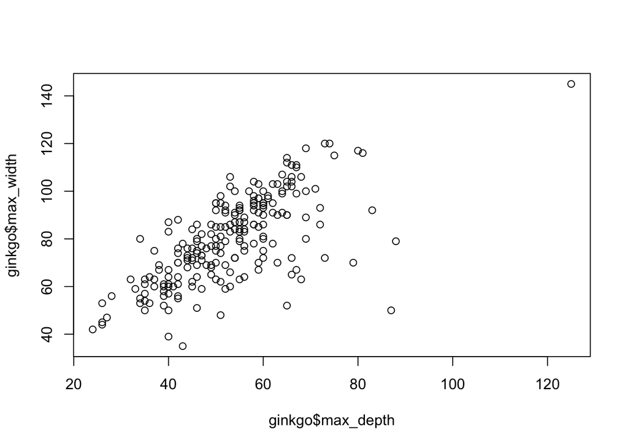

```r
## basic scatterplot, with max leaf depth on the x axis, and max leaf width on the y axis.
## x axis goes first, then y
plot(ginkgo$max_depth, ginkgo$max_width)
```

Now that you know what your basic plot looks like, it’s time to make it look nicer and easier to interpret. The arguments **main**, **xlab**, and **ylab** can edit your main title, title of your x axis, and title of your y axis. The arguments **xlim** and **ylim** specify what you want the range on your x and y axes to be. The arguments **col**, **pch**, and **cex** dictate what your point color, shape, and magnification.

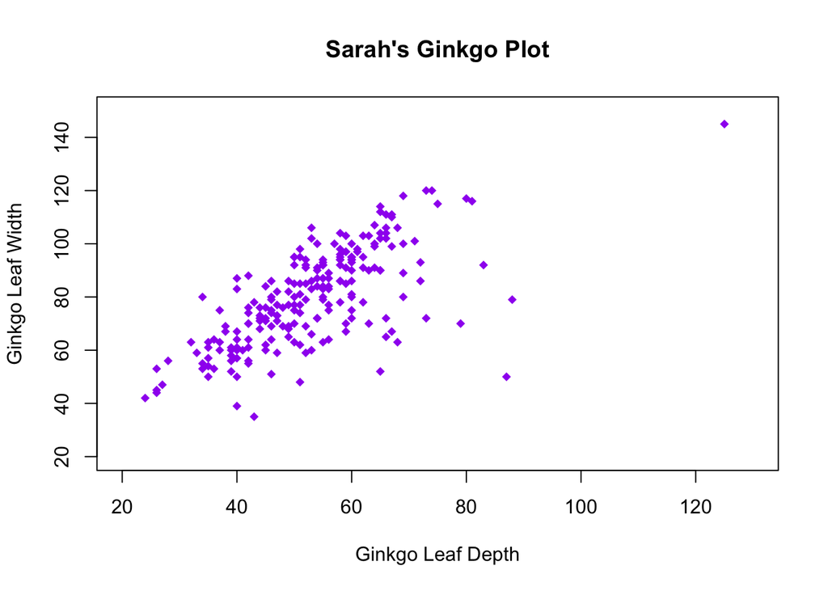

```r
plot(ginkgo$max_depth, ginkgo$max_width, main = "Sarah's Ginkgo Plot",
     xlab = "Ginkgo Leaf Depth", ylab = "Ginkgo Leaf Width", xlim = c(20, 130),
     ylim = c(20, 150), col = "purple", pch = 18, cex = 1)
```

#### Histograms

Histograms are really useful to see how your data is distributed. You can use the function hist() to creat them.

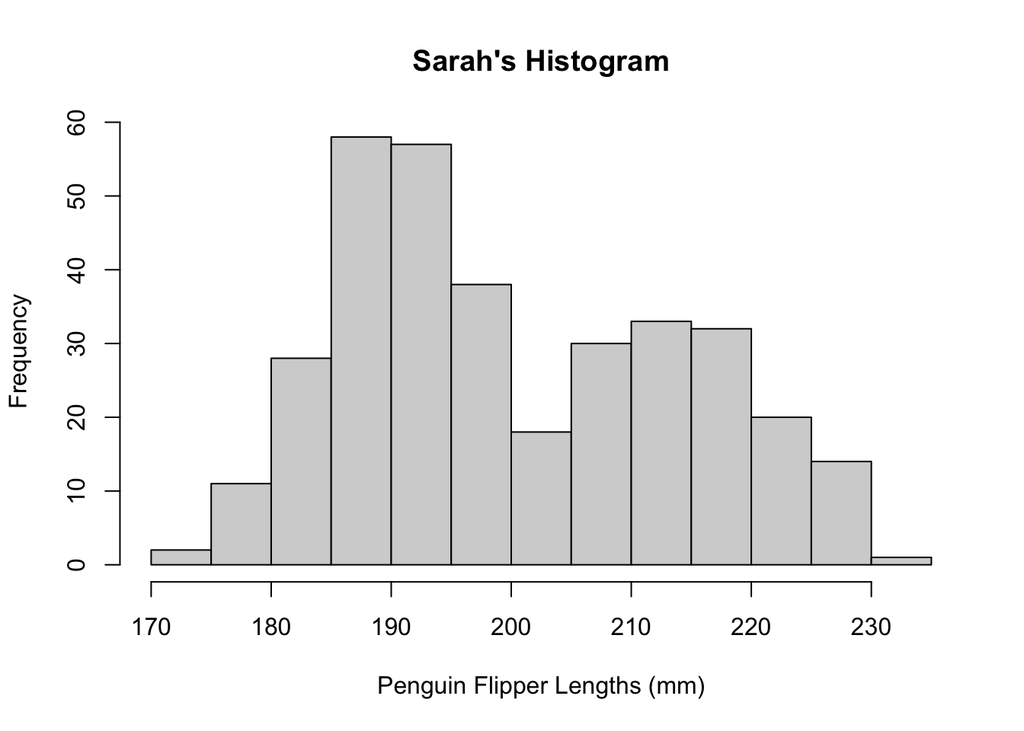

```r
hist(penguins$flipper_length_mm, main = "Sarah's Histogram", xlab = "Penguin Flipper Lengths (mm)")
```

Let’s say you don’t like how R chose to bin your data frequencies. You try to force R to change using the breaks argument. Let’s say I want 5 frequency bins

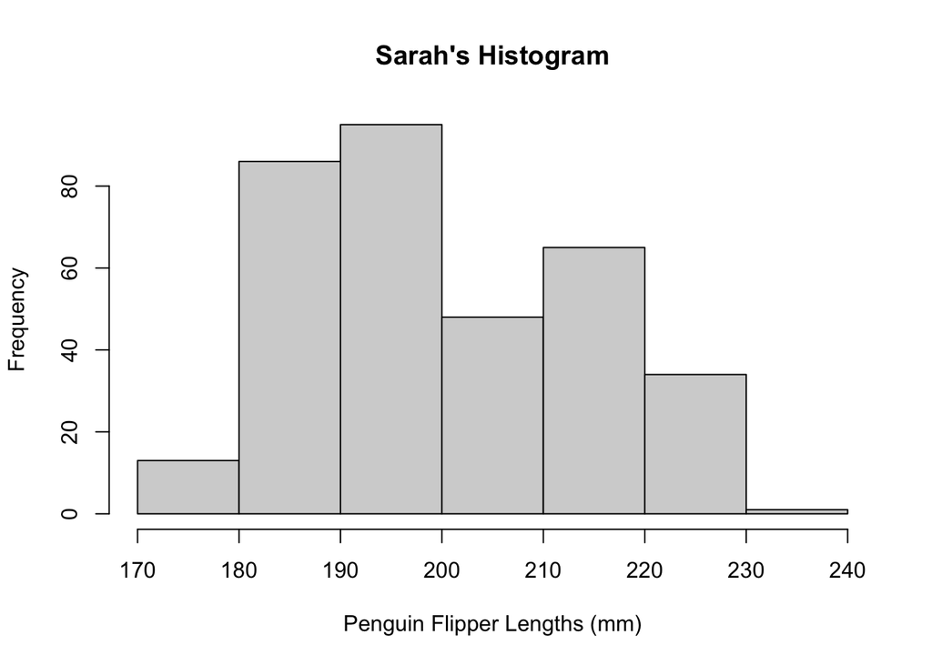

```r
## let's try just telling R to do 5 bins
hist(penguins$flipper_length_mm, breaks = 5, main = "Sarah's Histogram", xlab = "Penguin Flipper Lengths (mm)")
```

R didn’t listen to us and instead made 7 bins because it uses it as more of a suggestion. Instead, let’s specificy to R where we want our breakpoints to be.

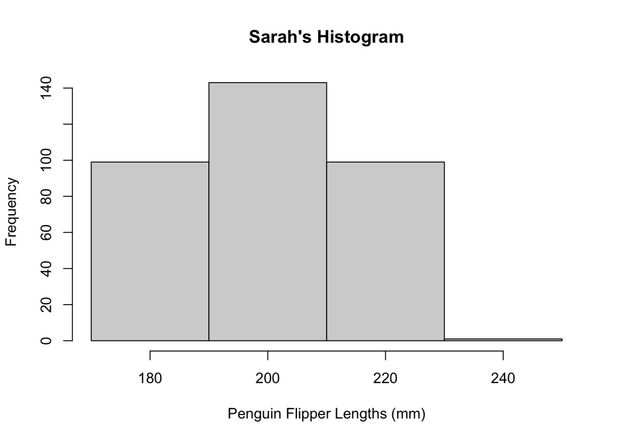

```r
## breakpoints at 20 mm intervals
hist(penguins$flipper_length_mm, breaks = c(170,190,210,230,250), main = "Sarah's Histogram", xlab = "Penguin Flipper Lengths (mm)")
```

It doesn’t look great, but we did it! We can also increase the number of bins within our histogram.

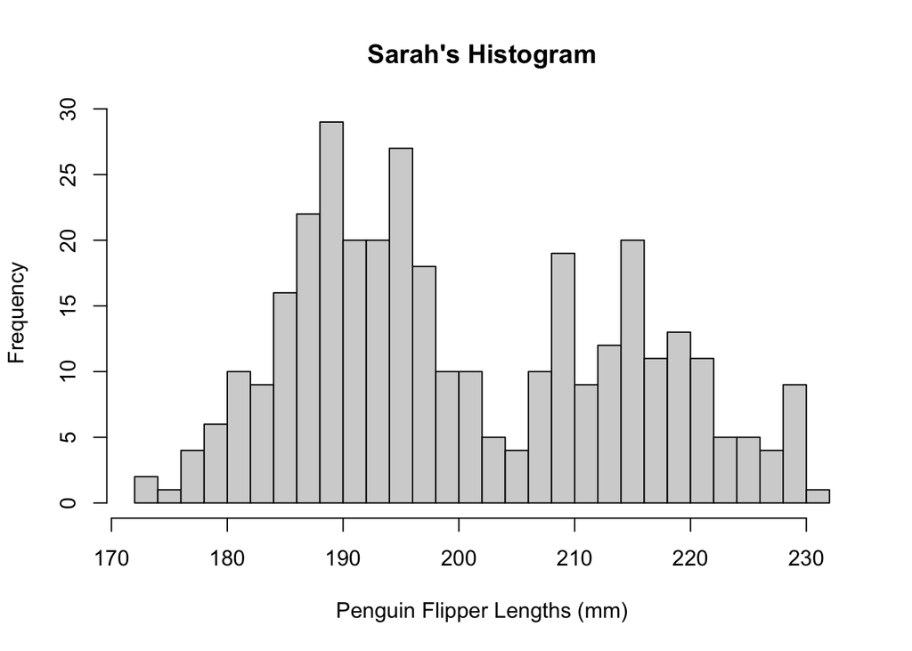

```r
## more breakpoints!
hist(penguins$flipper_length_mm, breaks = 30, main = "Sarah's Histogram", xlab = "Penguin Flipper Lengths (mm)")
```

#### Boxplots

Boxplots are made using the function boxplot(). They can tell the distribution of the data, outliers, minimum and maximum, median, and the 1st and 3rd quartile. Let’s make a simple boxplot of petiole lengths from the ginkgo dataframe. The same arguments can be made to give it titles and labels.

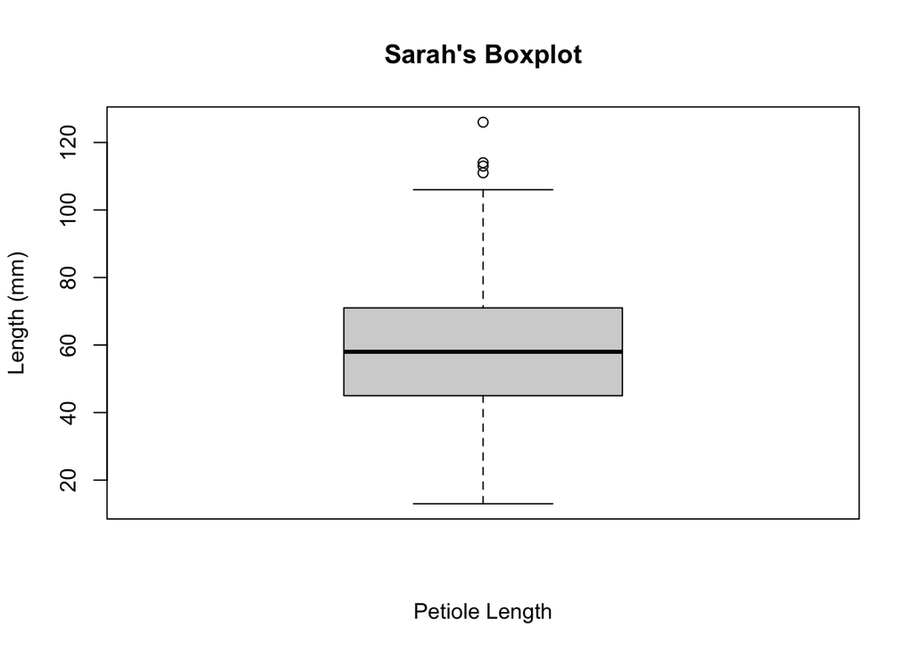

```r
boxplot(ginkgo$petiole_length, main = "Sarah's Boxplot", xlab = "Petiole Length",
        ylab = "Length (mm)")
```

Looks pretty good! Now let’s make another boxplot using a variable conditioned on the seeds.present column. This means that we will have two boxes within our plot, one showing our data where seeds are present, and the second showing our data where seeds are not present. Making a conditional boxplot is pretty easy, especially if you use the formula notation. The formula notation is as follows function(conditioned variable ~ conditional variable, data = dataframe). Since you have data = dataframe, you don’t even need to subset the column names with the data object name, you can simply use the name of the variables. See our boxplot below.

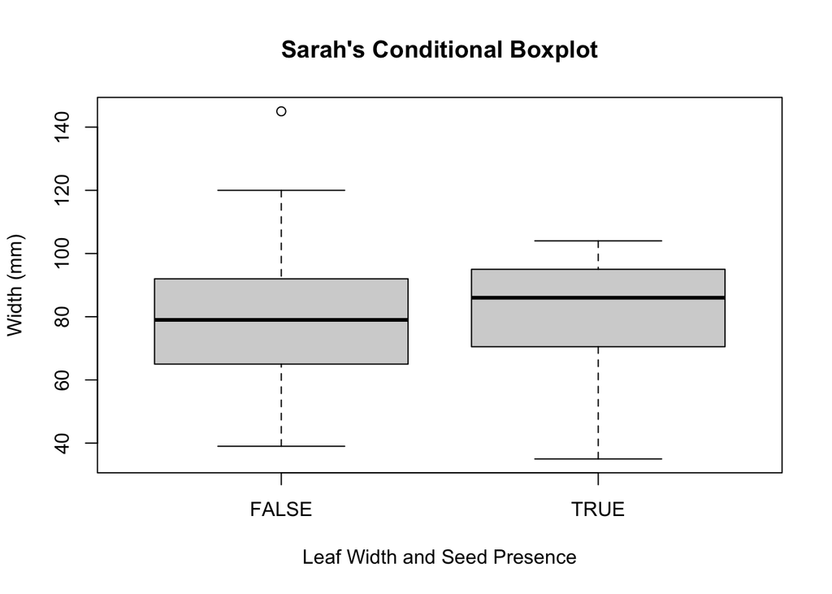

```r
boxplot(max_width ~ seeds_present, data = ginkgo, main = "Sarah's Conditional Boxplot",
        xlab = "Leaf Width and Seed Presence", ylab = "Width (mm)")
```

#### Using the par() Function

The par() function is great at putting graphs together in a panel and making them look nice. Let’s say we want a panel of histograms depictin the distribution of our penguin morphometric data. Using the par() function and the argument mfrow, we can tell it to create a 2 by 2 panel of histograms. By calling the function above the graphs, it will tell R to arrange the graphs according to our argument. If we want R to stop arranging graphs this way, we can use the function dev.off() after our last graph.

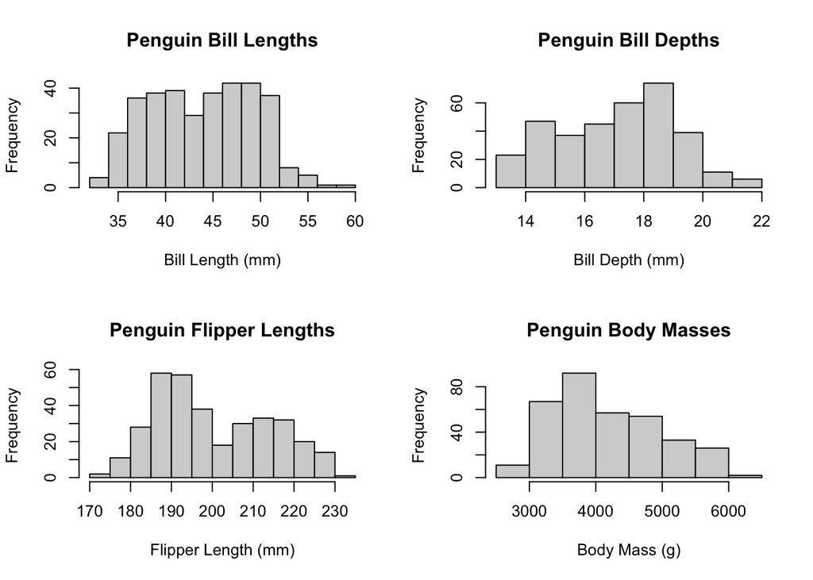

```r
par(mfrow = c(2,2))
hist(penguins$bill_length_mm, main = "Penguin Bill Lengths", xlab = "Bill Length (mm)")
hist(penguins$bill_depth_mm, main = "Penguin Bill Depths", xlab = "Bill Depth (mm)")
hist(penguins$flipper_length_mm, main = "Penguin Flipper Lengths",
     xlab = "Flipper Length (mm)")
hist(penguins$body_mass_g, main = "Penguin Body Masses", xlab = "Body Mass (g)")
```

```r
dev.off()
```